[figure not shown]

# Data Analysis

### Andrey Shestakov (avshestakov@hse.ru)

## Intoduction<sup>1</sup>

<sup>1. Materials used from machine learning course of Victor Kitov</sup>

### Some Friendly Faces

| Lectures: Andrey Shestakov | Seminars: Mikhail Gushin | Seminars: Radomir Britkov |
| --- | --- | --- |
|  | Seminars: Leyla Khatbullina | Seminars: Leonid Matyushin |

TAs: Natalia Zubkova, Anna Starovoyt, Anna Karbovskaya

# Course information

- Structure:
  - lectures, seminars
  - practical assignments ([anytask](https://anytask.org/)), competitions ([kaggle](https://www.kaggle.com/))
  - midterm colloquium
  - exam
- Evaluation:
  - cumulative score = 0.8 *$S_{\text{homework}}$ + 0.2* $S_{\text{colloq}}$+ 0.2 * $S_{\text{competition}}$
  - score = 0.7 *$S_{\text{cumulative}}$ + 0.3* $S_{\text{exam}}$
- Tools
  - python 3
  - Jupyter Notebook
  - numpy, scipy, pandas
  - matplotlib, seaborn
  - scikit-learn and more

# Recommended materials

- [**The Elements of Statistical Learning: Data Mining, Inference, and Prediction**](http://web.stanford.edu/~hastie/ElemStatLearn/) Trevor Hastie, Robert Tibshirani, Jerome Friedman
- **Data Mining: The Textbook** Charu C. Aggarwal, Springer, 2015.
- [**Mining Massive Datasets**](http://www.mmds.org/) Jure Leskovec, Anand Rajaraman, Jeff Ullman
- **Statistical Pattern Recognition.** 3rd Edition, Andrew R. Webb, Keith D. Copsey, John Wiley & Sons Ltd., 2011.
- [**Vorontsov's SHAD video lectures (Russian)**](https://yandexdataschool.ru/edu-process/courses/machine-learning).
- [**Vorontsov's textual lectures (Russian)**](http://www.machinelearning.ru/wiki/index.php?title=\%D0\%9C\%D0\%BE).
- Any additional public sources:
  - wikipedia, articles, tutorials, video-lectures.
- Practical questions:
  - [StackOverflow](https://stackoverflow.com/), [scikit-learn documentation](http://scikit-learn.org/stable/documentation.html), [kaggle forum](https://www.kaggle.com/getting-started)

# Plan 4 today

- Motivation to learn data analysis (data science, machine learning)
- Get used to some notations
- Problem types
- Feature types
- Some fundamental terminology, pics and memes

# Motivation

## Motivation

[figure not shown]

## Motivation

[figure not shown]

```python
YouTubeVideo('zvGeLvWZ7yQ', width=700, height=600)
```

[video not shown]

## Motivation

[figure not shown]

[50 years of data science](http://courses.csail.mit.edu/18.337/2015/docs/50YearsDataScience.pdf)

## Motivation

- Data scientist is a highly wanted and well-paid specialization.
- Apply boring calculus, linear algebra and statistics to problem solving.
- Should use **machine learning** "apparatus" to extract knowledge from data.

[figure not shown]

## Machine learning?

- Machine learning is a field of study that gives computers the ability to learn without being explicitly programmed.

[figure not shown]

## Examples

- Spam filtering
  - if sender belongs to black-list -> spam
  - if contains phrase 'buy now' and sender is unknown -> spam
  - ...
- Part-of-speech tagger.
  - if ends with 'ed' -> verb
  - if previous word is 'the' -> noun
  - ...
- ML finds decision rules automatically with labelled data!

# Formal problem statement

- Set of objects $O$
- Each object is described by a vector of known characteristics $\mathbf{x}\in\mathcal{X}$ and predicted characteristics $y\in\mathcal{Y}$. $$ o\in O\longrightarrow(\mathbf{x},y) $$
- **Task:** find a mapping $f$, which could accurately approximate $\mathcal{X}\to\mathcal{Y}$.
  - using a finite **known set** of objects (learning)
  - apply model for objects from the **test set** (prediction)
  - understand revealed relationships in data (inference, interpretation)

## Known Set

Known set: $(\mathbf{x}_{1},y_{1}),...(\mathbf{x}_{M},y_{M})$  
design matrix $X=[\mathbf{x}_{1},...\mathbf{x}_{M}]^{T}$, $Y=[y_{1},...y_{M}]^{T}$.

[figure not shown]

## Known Set

Known set: $(\mathbf{x}_{1},y_{1}),...(\mathbf{x}_{M},y_{M})$  
design matrix $X=[\mathbf{x}_{1},...\mathbf{x}_{M}]^{T}$, $Y=[y_{1},...y_{M}]^{T}$.

[figure not shown]

## Known Set

Known set: $(\mathbf{x}_{1},y_{1}),...(\mathbf{x}_{M},y_{M})$  
design matrix $X=[\mathbf{x}_{1},...\mathbf{x}_{M}]^{T}$, $Y=[y_{1},...y_{M}]^{T}$.

[figure not shown]

# Test set

- Known sample $X,Y$: $(\mathbf{x}_{1},y_{1}),...(\mathbf{x}_{M},y_{M})$
- Test sample $X',Y'$: $(\mathbf{x}_{1}',y_{1}'),...(\mathbf{x}_{K}',y_{K}')$

[figure not shown]

# Specification of ML tasks

- **supervised learning**: $(\mathbf{x}_{1},y_{1}),(\mathbf{x}_{2},y_{2}),...(\mathbf{x}_{N},y_{N})$
  - e.g. regression, classification.
- **unsupervised learning**: $\mathbf{x}_{1},\mathbf{x}_{2},...\mathbf{x}_{N}$
  - e.g. dimensionality reduction, clustering, outlier analysis, topic modelling

# Toy examples

## Regression 1

[figure not shown]

Predict $y\in\mathbb{R}$ for any $x$

## Regression 2

[figure not shown]

- Obviously, those characteristics somehow relate with price ($f: X \rightarrow Y$)
- Formalize a model to predict flat price: $$a(x) = a(total\_area, nmbr\_of\_bedrooms, house\_age) = \hat{y}$$
- Let it be a linear model: $$a(x) = w_0 + w_1\cdot total\_area + w_2 \cdot nmbr\_of\_bedrooms + w_3 \cdot house\_age$$
- Learning - find coefficients $w_0,\dots, w_3$, that minimizer error on training set

## Classificaion 1

[figure not shown]

Predict class $y$ shown with color for any point.

## Classification 2

#### Inbox message classification

Help user organize email inbox

[figure not shown]

- Natual Language Processing

## Unsupervised Learning. Clustering

[figure not shown]

## Clustering

[figure not shown]

## Unsupervised Learning. Dimensionality reduction

[figure not shown]

Reduce dimension from 3D to 2D with minimal distortion.

## Unsupervised Learning. Topic modelling

[figure not shown]

Describe huge document with a low-dimentional sparse vector

## Outlier Detection Task

[figure not shown]

Detect untypical observations.

## Recommender Systems

[figure not shown]

## Recommender Systems

[figure not shown]

## Ranking

[figure not shown]

# Reinforcement learning

- RL setup:
  - a set of environment and agent states $S$;
  - a set of actions $A$, of the agent
  - $P(s_{t+1}=s'|s_{t}=s,a_{t}=a)$ is the probability of transition from state s to state s' under action a.
  - $R_{a}(s,s')$ is the (expected) immediate reward after transition from $s$ to $s'$ with action $a$.
- Well-suited to problems which include a long-term versus short-term reward trade-off
- Applications: robot control, elevator scheduling, games (chess, go, **DOTA**), etc.

```python
YouTubeVideo('V1eYniJ0Rnk', width=700, height=600)
```

[video not shown]

# General Problem Statement

- We want to approximate $f(x):\,X\to Y$
- Questions in ML:
  - what target $y$ we are predicting?
  - how to select object descriptors (features) $x$?
  - what type of mapping $f$?
  - in what sense a mapping $f$ should approximate true relationship?
  - how to tune $f$?

# What target $y$ we are predicting?

## Types of target variable (supervised learning)

- $\mathcal{Y}=\mathbb{R}$ - regression
  - e.g. flat price
- $\mathcal{Y}=\mathbb{R}^{M}$ - vector regression
  - e.g. stock price dynamics

## Types of target variable (supervised learning)

- $\mathcal{Y}=\{\omega_{1},\omega_{2},...\omega_{C}\}$ - classification.
  - C=2: binary classification.
  - e.g. spam / not spam (ham)
- C>2: multi-class classification
  - e.g. identity recognition, activity recognition
- $\mathcal{Y}$ - any subset of $\{\omega_{1},\omega_{2},...\omega_{C}\}$ - labeling
  - e.g. news categorization

# How to select object descriptors (features) 𝑥?

## Types of features

- Full object description $\mathbf{x}\in\mathcal{X}$ consists of individual features $x^{i}\in\mathcal{X}_{i}$
- Types of feature (e.g. for credit scoring):
  - $\mathcal{X}_{i}=\{0,1\}$ - binary feature
    - e.g. marital status
  - $|\mathcal{X}_{i}|<\infty$ - categorical (nominal) feature
    - e.g. occupation
  - $|\mathcal{X}_{i}|<\infty$ and $\mathcal{X}_{i}$ is ordered - ordinal feature
    - e.g.education level
  - $\mathcal{X}_{i}=\mathbb{R}$ - continuous feature
    - e.g. age

### Credit scoring

- Objects — credit applicantion
- Target — return credit of not
- Kind of task and features?

### Credit scoring

- Binary: sex,
- Categorical: living region, profession, marital status
- Ordinal: education level, work grade
- Continuous: age, wage

### Churn prediction

- Object — online game user
- Target — will he/she lose interest in playing after 2 weeks?
- Kind of task and features?

### Churn prediction

- Binary: premium user
- Categorical: avatar class, game plan
- Continuous: average playing hours per day, number of characters, chat activity

# What type of mapping 𝑓?

# In what sense a mapping 𝑓 should approximate true relationship?

## Learning = Representation + Evaluation + Optimization

[A Few Useful Things to Know about Machine Learning](https://homes.cs.washington.edu/~pedrod/papers/cacm12.pdf) // Pedro Domingos

## Model Class (Representation)

### Linear Example

- **Function class** - parametrized set of functions $F=\{f_{\theta},\,\theta\in\Theta\}$, from which the true relationship $\mathcal{X}\to\mathcal{Y}$ is approximated.
  - **Regression**: $\widehat{y}=f(x|\theta)$,
  - **Classification**: $\widehat{y}=f(x|\theta)=\arg\max_{c}\left\{ g_{c}(x|\theta)\right\} $, $c=1,2,...C$.
    - $c=1,2,...C$: possible classes, $g_{c}(x)$ - score of class $c$, given $x$ called *discriminant function*

## Examples

[output not shown]

## Loss function vs model quality (Evaluation)

- In machine learning models try to optimize some function, which you can call:
  - **score, rating** - if you are maximizing
  - **loss, cost, error** - if you are minimized
  - both score and loss can be computed for individual objects
  - directly optimized in model
- Model **quality measures** are used to compare diffrent models' performance on test set
  - some of them can not be directly optimized in the model
  - usually can not be computed for individual objects

## Loss function $\mathcal{L}(\widehat{y},y)$

- **regression**:
  - MAE (mean absolute error): $$ \mathcal{L}(\widehat{y},y)=\frac{1}{N}\sum\limits_i\left|\widehat{y}_i-y_i\right| $$
  - MSE (mean squared error): $$ \mathcal{L}(\widehat{y},y)=\frac{1}{N}\sum\limits_i\left(\widehat{y}_i-y_i\right)^{2} $$

[figure not shown]

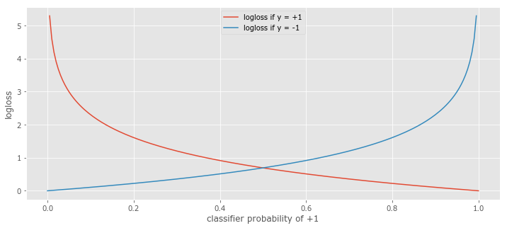

```python
plt.plot(h, L1, label='logloss if y = +1')
plt.plot(h, L2, label='logloss if y = -1')
plt.ylabel('logloss')
plt.xlabel('classifier probability of +1')

_ = plt.legend()
```

## Optimization

# How to tune $f$?

## Overfitting - Underfitting

- Theoretically, a very complex model can achive perfect quality on training dataset
- Profit???
- Nope...

## Overfitting - Underfitting

[figure not shown]

## Empirical risk

- Want to minimize *expected risk*: $$ \mathit{\int}\int\mathit{\mathcal{L}(f_{\theta}(\mathbf{x}),y) \cdot p(\mathbf{x},y)d\mathbf{x}dy\to\min_{\theta}} $$
- In fact we have only $X$,$Y$ (Known set) and $X'$ (Test set)
- Can minimize *empirical risk* $$ L(\theta|X,Y)=\frac{1}{N}\sum_{n=1}^{N}\mathcal{L}(f_{\theta}(\mathbf{x}_{n}),\,y_{n}) $$
- Method of empirical risk minimization: $$ \widehat{\theta}=\arg\min_{\theta}L(\theta|X,Y) $$
- How to get realistic estimate of $L(\widehat{\theta}|X',Y')$?
  - separate **validation set**
  - **cross-validation**
  - **leave-one-out** method

# Separate validation set

- Known sample $X,Y$: $(\mathbf{x}_{1},y_{1}),...(\mathbf{x}_{M},y_{M})$
- Test sample $X',Y'$: $(\mathbf{x}_{1}',y_{1}'),...(\mathbf{x}_{K}',y_{K}')$

[figure not shown]

# Separate validation set

Divide known set randomly or randomly with stratification:

[figure not shown]

## Cross-validation

### 4-fold cross-validation example

[figure not shown]

Divide training set into K parts, referred as **folds** (here $K=4$).

Variants:

- randomly
- randomly with stratification (w.r.t target value or feature value)
- randomly with respect to time domain
- etc

### 4-fold cross-validation example

[figure not shown]

Use folds 1,2,3 for model estimation and fold 4 for model evaluation.

### 4-fold cross-validation example

[figure not shown]

### 4-fold cross-validation example

[figure not shown]

### 4-fold cross-validation example

[figure not shown]

### 4-fold cross-validation example

- Denote
  - $k(n)$ - fold to which observation $(\mathbf{x}_{n},y_{n})$ belongs $n\in I_{k}$.
  - $\widehat{\theta}^{-k}$ - parameter estimation using observations from all folds except fold $k$.

**Cross-validation empirical risk estimation**

$$\widehat{L}_{total}=\frac{1}{N}\sum_{n=1}^{N}\mathcal{L}(f_{\widehat{\theta}^{-k(n)}}(x_{n}),\,y_{n})$$

- For $K$-fold CV we have:
  - $K$ parameters $\widehat{\theta}^{-1},...\widehat{\theta}^{-K}$
  - $K$ models $f_{\widehat{\theta}^{-1}}(\mathbf{x}),...f_{\widehat{\theta}^{-K}}(\mathbf{x}).$
  - $K$ estimations of empirical risk: $\widehat{L}_{k}=\frac{1}{\left|I_{k}\right|}\sum_{n\in I_{k}}\mathcal{L}(f_{\widehat{\theta}^{-k}}(\mathbf{x}_{n}),\,y_{n}),\,k=1,2,...K.$
    - can estimate variance & use statistics!

## Comments on cross-validation

- When number of folds $K$ is equal to number of objects $N$, this is called **leave-one-out method**.
- Cross-validation uses the i.i.d.(independent and identically distributed) property of observations
- Stratification by target $y$ helps for imbalanced/rare classes.

# A/B testing

## A/B testing

- Observe test set **after the models were built**.
- A/B testing procedure:
  1. divide test objects randomly into two groups - A and B.
  2. apply base model to A
  3. apply modified model to B
  4. compare final results\pause

# Modelling Pipelines

## General Modelling Pipeline

[figure not shown]

If evaluation gives poor results we may return to each of preceding stages.

## CRISP DM

[figure not shown]

# Summary

- Machine learning algorithms reconstruct relationship between features $x$ and outputs $y$.
- Relationship is reconstructed by optimal function $\widehat{y}=f_{\widehat{\theta}}(x)$ from function class $\{f_{\theta}(x),\,\theta\in\Theta\}$.
- $\theta$ is particular controls model complexity, models may be too simple and too complex.
- $\widehat{\theta}$ selected to minimize empirical risk $\frac{1}{N}\sum_{n=1}^{N}\mathcal{L}(f_{\theta}(x_{n}),y_{n})$ for some loss function $\mathcal{L}(\widehat{y},y)$.
- Overfitting - non-realistic estimate of expected loss on the training set.
- To avoid overfitting - use validation sets, cross-validation, A/B test.

# FYI

- [Open Data Science Russion Community](http://ods.ai/)
- [ML Trainings](https://www.youtube.com/channel/UCeq6ZIlvC9SVsfhfKnSvM9w)
- [Kaggle](https://www.kaggle.com/)